# Feature Importance in Neural Networks

- 01 Overview
- 02 Complete
  - Generating Data
  - Defining Model
  - Evaluating Model
  - Animated Bar Graph
  - Box Plot
  - Standard Deviation
  - Scatter Plots
  - Probability Density
  - Feature Importance
- 03 One Value
  - Box Plot
  - Probability Density
  - Feature Importance
- 04 Accuracy
  - Dataset 1 Results
  - Dataset 2 Results
  - Dataset 3 Results
- 05 Classification
  - Box Plot
  - Probability Density
  - Feature Importance
- 06 Titanic
  - Random Forest
  - Neural Network
  - Comparison

# One Value, One Noise

In this example, we examine the effect on the weights for a neural network trained on one important value and one noise value. This is useful as a means to see if the noise is completely tuned out or if another mechanism is in place.

## Imports

```python
import math
import warnings

from typing import List, Dict
from statistics import mean, stdev
from random import randint

import pandas as pd
import tensorflow as tf
import matplotlib
import matplotlib.pyplot as plt
import numpy as np
from tensorflow.keras.optimizers import Adam
from scipy.stats import norm

warnings.filterwarnings("ignore")

matplotlib.rcParams["animation.embed_limit"] = 2**128
matplotlib.rcParams["figure.dpi"] = 300
```

## Generating data

The data used for this notebook follows the equation $y = x$. To ensure replicable results as well as keeping the network's topology as simple as possible, the values for **x's** are randomly generated. There is the addition of a **noise** column that is purely there as a target for the network to tune out.

```python
SAMPLES = 5000
```

```python
def generate_random_values():
    return [randint(0,50) * randint(0,50) for _ in range(SAMPLES)]

xs = generate_random_values()

ys = xs

noise = [randint(0,100) for _ in range(SAMPLES)]

data = {
    "xs": xs,
    "noise": noise,
    "ys": ys
}

df = pd.DataFrame(data=data)
split = 500

train = df.iloc[split:]
test = df.iloc[:split]
train.shape, test.shape
```

```
((4500, 3), (500, 3))
```

```python
X_train = train[["xs", "noise"]]
y_train = train["ys"]
X_test = test[["xs", "noise"]]
y_test = test["ys"]
```

```python
def create_history(columns: int, nodes: int) -> Dict:
    return {i:{j: [] for j in range(nodes)} for i in range(columns)}
```

```python
FIRST_LAYER = 1
```

```python
history = create_history(len(X_train.columns), FIRST_LAYER)
```

## Defining Model

```python
model = tf.keras.Sequential()
model.add(tf.keras.layers.Dense(FIRST_LAYER, activation='relu'))
model.add(tf.keras.layers.Dense(units=1))
opt = Adam(0.01)
model.compile(optimizer=opt, loss="mean_squared_error")
```

```python
for epoch in range(1, 501):
    print(f"RUNNING EPOCH {epoch}")
    hist = model.fit(X_train, y_train, epochs=1, batch_size=100)
    all_weights = model.layers[0].get_weights()[0].tolist()
    for weights in range(len(all_weights)):
        for weight in range(len(all_weights[weights])):
            history[weights][weight].append(all_weights[weights][weight])
```

## Evaluating Model

```python
res_xs = X_test["xs"].values.tolist()
res_noise = X_test["noise"].values.tolist()
res_pred = [
    round(i) for i in model.predict(X_test).flatten().tolist()
]
res = {
    "xs": res_xs,
    "noise": res_noise,
    "ys": y_test,
    "pred": res_pred
}

res = pd.DataFrame(res)
res
```

|  | xs | noise | ys | pred |
| --- | --- | --- | --- | --- |
| 0 | 66 | 24 | 66 | 66 |
| 1 | 21 | 19 | 21 | 21 |
| 2 | 792 | 2 | 792 | 792 |
| 3 | 432 | 25 | 432 | 432 |
| 4 | 658 | 99 | 658 | 658 |
| ... | ... | ... | ... | ... |
| 495 | 672 | 27 | 672 | 672 |
| 496 | 1617 | 47 | 1617 | 1617 |
| 497 | 70 | 79 | 70 | 70 |
| 498 | 858 | 14 | 858 | 858 |
| 499 | 119 | 64 | 119 | 119 |

500 rows × 4 columns

```python
expected = list(res["ys"].values)
actual = list(res["pred"].values)
accuracies = []
for i in range(len(expected)):
    if expected[i] > actual[i]:
        accuracies.append((actual[i] / expected[i]) * 100)
    elif expected[i] < actual[i]:
        accuracies.append((expected[i] / actual[i]) * 100)
    else:
        accuracies.append(100)
print(f"The model is correct to {round(mean(accuracies), 5)}%")
```

```
The model is correct to 100%
```

## Colors

Here we use the same colors throughout to represent the values:

- Important Value (x)
- Noise Value (noise)
- Box Plot Fliers (other)

```python
important = "#F3D250"
noise = "#F78888"
other = "#ECECEC"
```

## Splitting weights into groups

```python
def get_groups(index: int, nodes: int) -> List:
    group = []
    for i in range(nodes):
        group.append(history[index][i])
    return group
```

```python
xs = get_groups(0, 1)
noises = get_groups(1, 1)
```

## Box Plots

```python
def generate_box_plot(
    ax,
    data: List,
    color: str,
    label: str,
    position_offset: int = 0,
    showfliers: bool = False
):
    ax.set_xlabel("Input Column and Node Number")
    ax.set_ylabel("Weight Values")
    color = {"color": color}
    ax.boxplot(
        data,
        positions=[i + position_offset for i in range(1,2)],
        boxprops=color,
        medianprops=color,
        whiskerprops=color,
        capprops=color,
        flierprops={"markeredgecolor": other},
        showfliers=showfliers,
        labels=[f"{label} {i}" for i in range(1, 2)]
    )
```

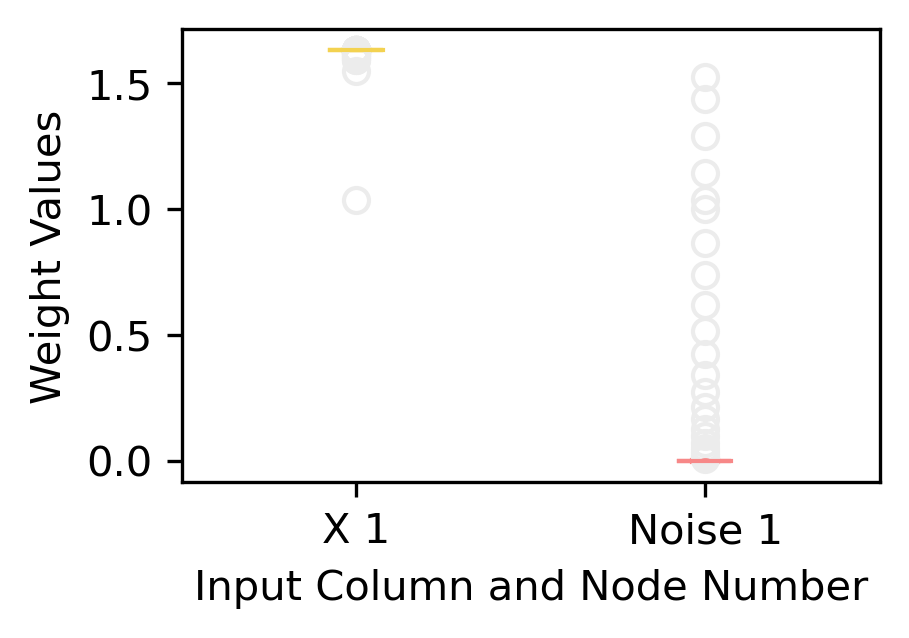

```python
fig, ax = plt.subplots(figsize=(3,2))

generate_box_plot(
    ax,
    xs,
    important,
    "X",
    showfliers=True
)

generate_box_plot(ax,
    noises, noise, "Noise", 1, showfliers=True)
```

## Standard Deviation

```python
data = {
    "x_one": xs[0],
    "noise_one": noises[0],
}

columns = [
    "x_one",
    "noise_one",
]


odf = pd.DataFrame(data)
odf.head(5)
```

|  | x_one | noise_one |
| --- | --- | --- |
| 0 | 1.037560 | 1.035953 |
| 1 | 1.551534 | 1.527711 |
| 2 | 1.591524 | 1.437197 |
| 3 | 1.594854 | 1.289712 |
| 4 | 1.600491 | 1.143745 |

```python
std_df = odf.std().to_frame()
mean_df = odf.mean().to_frame()
std_df.columns = ["Std"]
mean_df.columns = ["Mean"]
merged_df = pd.merge(std_df, mean_df, left_index=True, right_index=True)
```

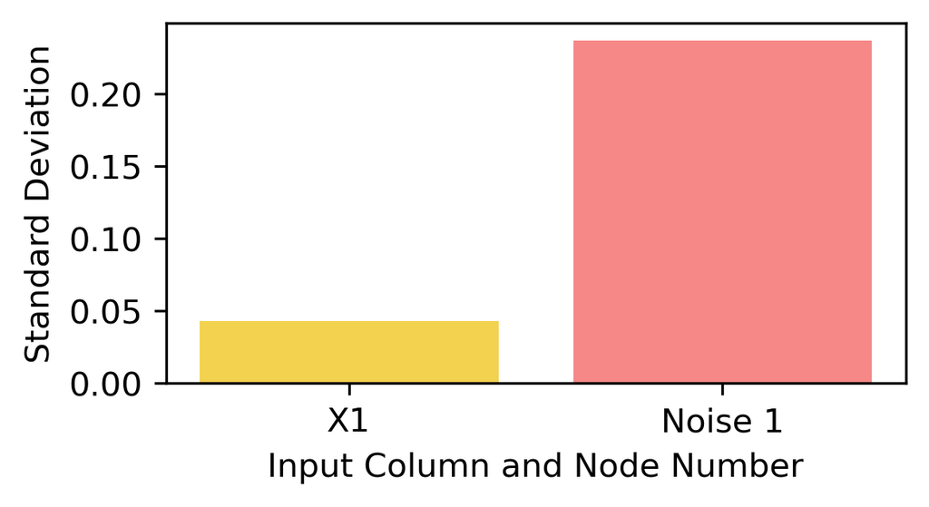

```python
fig, ax = plt.subplots(figsize=(4, 2))
ax.bar(
    [
        "X1",
        "Noise 1",
    ],
    [
        std_df["Std"].loc["x_one"],
        std_df["Std"].loc["noise_one"],
    ],
    color=[
        important,
        noise,
    ],
)
ax.set_xlabel("Input Column and Node Number")
ax.set_ylabel("Standard Deviation")
;
```

## Probability Densities

```python
def get_group_by_node() -> List:
    return [history[0][0], history[1][0]]
```

```python
group = get_group_by_node()
```

```python
def plot_stds(group):
    _, ax = plt.subplots(figsize=(16,6))
    domain = np.linspace(-2,2,1000)
    means = [mean(group[0]), mean(group[1])]
    stds = [stdev(group[0]), stdev(group[1])]
    colors = [important, noise]

    for mu, std, color in zip(means, stds, colors):
        probs = norm.pdf(domain, mu, std)
        ax.plot(domain, probs, color=color)
        ax.set_xlabel("Weight")
        ax.set_ylabel("Probability Density")
```

[figure not shown]

```python
plot_stds(group)
```

## Ranking Feature Importance

```python
def get_props(group):
    domain = np.linspace(-2,2,1000)
    means = [mean(group[0]), mean(group[1])]
    stds = [stdev(group[0]), stdev(group[1])]
    results = []
    for mu, std in zip(means, stds):
        values = []
        probs = norm.pdf(domain, mu, std)
        for prob in probs:
            if math.floor(prob) != 0:
                values.append(prob)
        results.append(values)
    return results
```

```python
all_probs = [get_props(group)]
```

```python
def barrage(all_probs, nodes: int):
    res = {
        i: {"len": 0, "max": 0, "sum": 0, "mean": 0, "stdev": 0} for i in range(nodes)
    }
    for probs in all_probs:
        for i, prob in enumerate(probs):
            res[i]["len"] += len(prob)
            res[i]["max"] += max(prob)
            res[i]["sum"] += sum(prob)
            res[i]["mean"] += mean(prob)
            res[i]["stdev"] += stdev(prob)
    return res
```

```python
columns = ["xs", "noises"]

res = barrage(all_probs, len(columns))
for i in range(len(columns)):
    res[columns[i]] = res.pop(i)
df = pd.DataFrame(res)
df
```

|  | xs | noises |
| --- | --- | --- |
| len | 46.000000 | 121.000000 |
| max | 9.303556 | 1.683810 |
| sum | 241.878116 | 173.183534 |
| mean | 5.258220 | 1.431269 |
| stdev | 2.863033 | 0.212610 |

```python
def plot_barrage(method: str):
    cdict = {"xs": important, "noises": noise}
    data = pd.Series(df.loc[method], df.columns).sort_values(ascending=True)
    cmap = [cdict[i] for i in list(data.index.values)]
    ax = data.plot.barh(width=0.8, figsize=(3, 1), color=cmap)
    ax.set_ylabel("Input")
    ax.set_xlabel(method.capitalize())
```

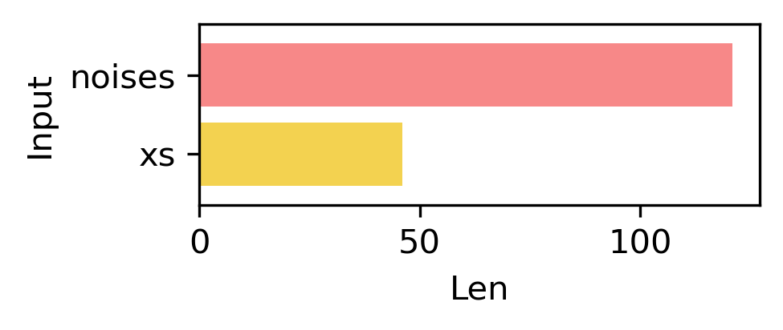

```python
plot_barrage("len")
```

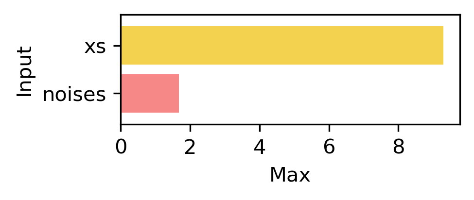

```python
plot_barrage("max")
```

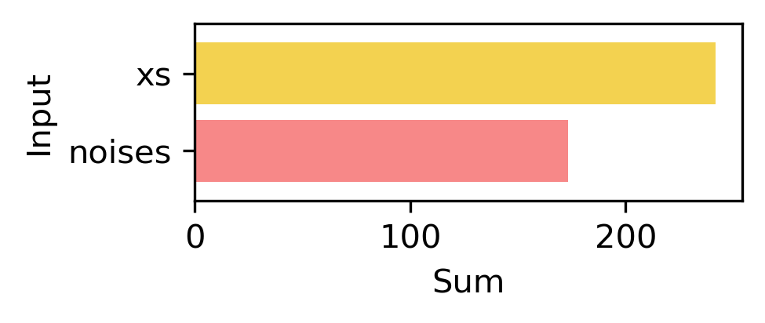

```python
plot_barrage("sum")
```

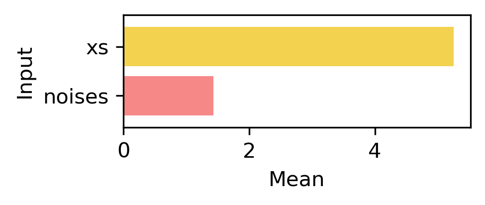

```python
plot_barrage("mean")
```

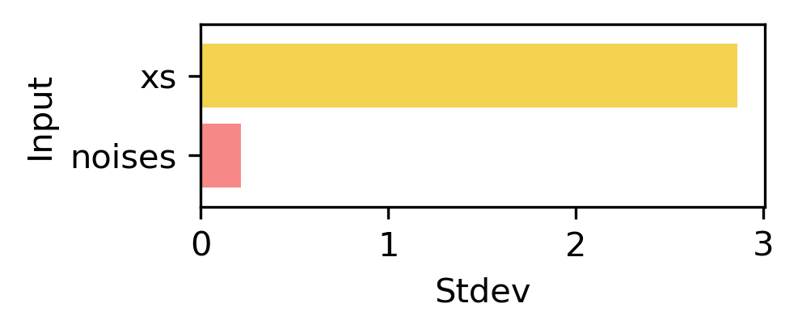

```python
plot_barrage("stdev")
```